# Memory Decay in ACT-R

Andrea Stocco

10/16/2016

## Memory decay in ACT-R

First, we create two variables:

```r
d <- 0.25
t <- seq(0, 120, 0.1)
```

## Creating the time traces

We now create four time traces. Each time trace is calculating using ACT-R’s decay equation, where the base-level activation $B_i$ of a chunk $i$ follows the function $B_i = \log (t_i^{-d})$. For simplicity, we assign a value of $B_i = 0$ for values of $t_i < 0$.

1. `t0` corresponding to the creation of the chunk at $t = 0$
2. `t20` corresponding to the first retrieval after 20 seconds, $t = 20$
3. `t70` corresponding to the second retrival after 50 more seconds, at $t = 70$
4. `t75` corresponding to a third retrieval 5 seconds after the second, at $t = 75$

```r
t0 <- ifelse (t <= 0, 0, t ** (-1 * d))
t20 <- ifelse (t <= 20, 0, (t - 20) ** (-1 * d))
t70 <- ifelse (t <= 70, 0, (t - 70) ** (-1 * d))
t75 <- ifelse (t <= 75, 0, (t - 75) ** (-1 * d))
```

Now, we can plot the timecourses of four traces separately

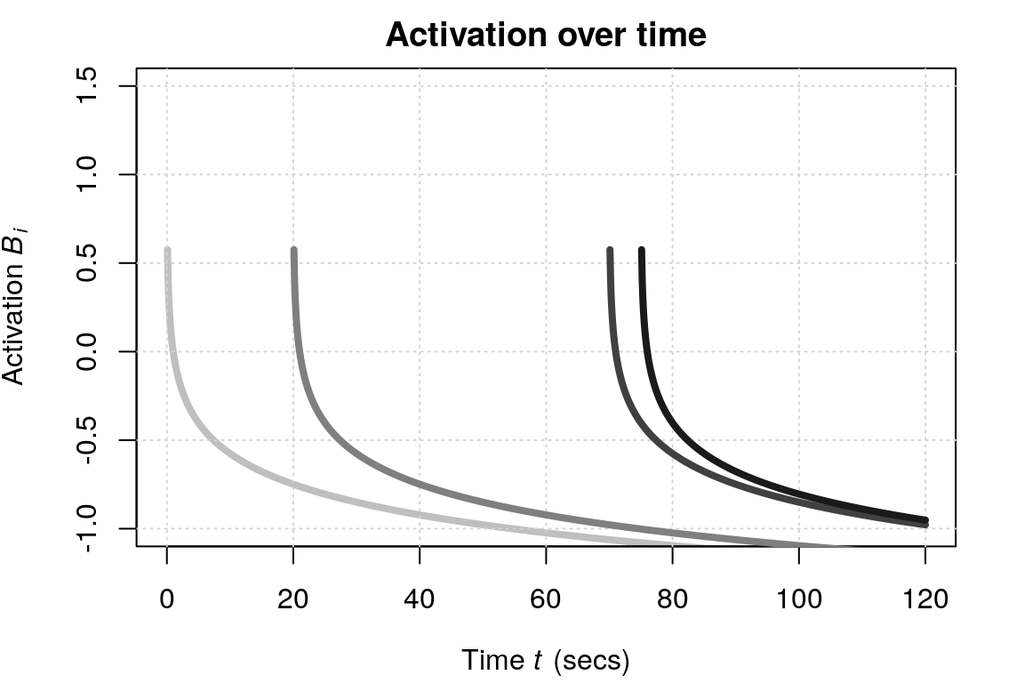

```r
par(mar=c(4,4,2,2))
ylab <- expression(paste("Activation ", italic(B)[italic(i)]))
xlab <- expression(paste("Time ", italic(t), " (secs)"))
plot(x = t, y = log(t0), lwd = 4, col="grey75", main = "Activation over time", type = "l", ylab = ylab, xlab = xlab, ylim=c(-1, 1.5))
grid()

lines(x = t, y = log(t20), lwd = 4, col="grey50")
lines(x = t, y = log(t70), lwd = 4, col="grey25")
lines(x = t, y = log(t75), lwd = 4, col="grey10")
```

Now, the total activation $B_i$ is simply the sum of all the traces $t_1, t_2 ... t_N$:

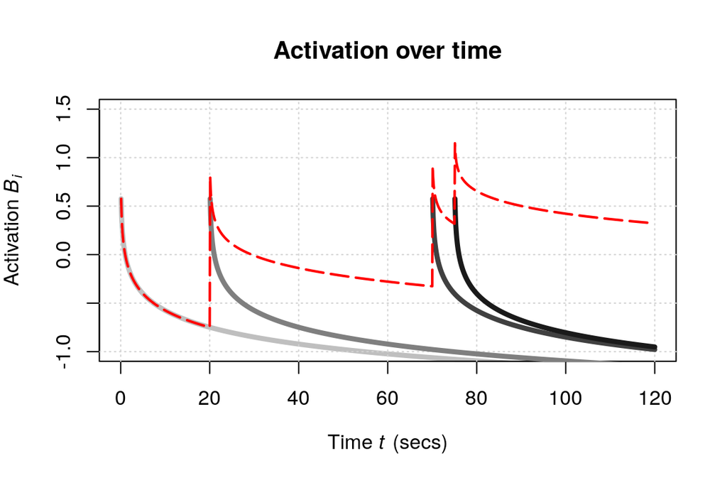

```r
plot(x = t, y = log(t0), lwd = 4, col="grey75", main = "Activation over time", type = "l", ylab = ylab, xlab = xlab, ylim=c(-1, 1.5))
grid()

lines(x = t, y = log(t20), lwd = 4, col="grey50")
lines(x = t, y = log(t70), lwd = 4, col="grey25")
lines(x = t, y = log(t75), lwd = 4, col="grey10")
lines(x = t, y = log(t0 + t20 + t70 + t75), lwd = 2, lty=5, col="red")
```

## Efficient approximation

The efficient approximation to $B_i$, or $B'_i$ is calculated as

Where $t_0$ is the time at which the chunk $i$ was created.

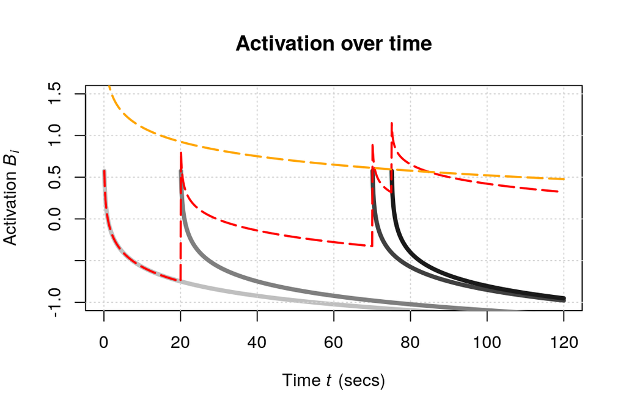

```r
plot(x = t, y = log(t0), lwd = 4, col="grey75", main = "Activation over time", type = "l", ylab = ylab, xlab = xlab, ylim=c(-1, 1.5))
grid()

lines(x = t, y = log(t20), lwd = 4, col="grey50")
lines(x = t, y = log(t70), lwd = 4, col="grey25")
lines(x = t, y = log(t75), lwd = 4, col="grey10")
lines(x = t, y = log(t0 + t20 + t70 + t75), lwd = 2, lty=5, col="red")

# Efficient approximation
# -----------------------
ol <- log(4 / (1 - d)) - d * log(t)
lines(x = t, y = ol, lwd = 2, lty=5, col="orange")
```

With memory effect B0

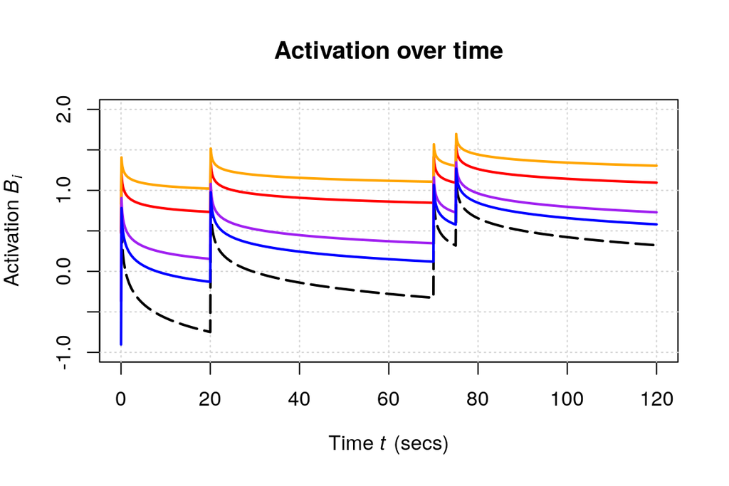

```r
V1 <- 10
V2 <- 5
V3 <- 2
V4 <- 1.5

plot(x = t, y = log(t0), lwd = 4, col="white", main = "Activation over time", type = "l", ylab = ylab, xlab = xlab, ylim=c(-1, 2))
grid()

lines(x = t, y = log(t0 + t20 + t70 + t75), lwd = 2, lty=5, col="black")

lines(x = t, y = log(t0 + t20 + t70 + t75 + log(V2)), lwd = 2, lty=1, col="red")

lines(x = t, y = log(t0 + t20 + t70 + t75 + log(V1)), lwd = 2, lty=1, col="orange")

lines(x = t, y = log(t0 + t20 + t70 + t75 + log(V3)), lwd = 2, lty=1, col="purple")

lines(x = t, y = log(t0 + t20 + t70 + t75 + log(V4)), lwd = 2, lty=1, col="blue")
```